# Spectral analysis and observation processing example

# 5. Ad-hoc analysis and alternative initialization

Let’s go back to our original example.

## 5.1. Processing on observations and items

### 5.1.1. Items, proportions and co-occurrences

Enumerate all substances in the list of observations…

```r
get_all_items(sa_object["observations"])
```

```
 [1]   19   25   27   49   57   71   77   87  148  163  192  252  328  402  497  929  930  931 1603
[20] 3146 3156 3157 3180 3345 3350
```

Count the number of occurrences of each substance (which is not necessarily the number of observations containing the substance)…

```r
# List of substances by observation (simply extract the "CODE" elements of each one)
substances_by_obs <- lapply(sa_object["observations"], "[[", "CODE")
# Total number of occurrences of each substance
table_on_list(substances_by_obs)
```

```
  19   25   27   49   57   71   77   87  148  163  192  252  328  402  497  929  930  931 1603 3146
   1    3    1    1    1    1    1    1    1    1    2    3    2    2    3    1    1    3    1    5
3156 3157 3180 3345 3350
   1    2    3    2    1
```

```r
# Number of involvement of each substance in multiple exposures
complexity_index(sa_object["observations"])
```

```
  19   25   27   49   57   71   77   87  148  163  192  252  328  402  497  929  930  931 1603 3146
   1    3    1    1    1    1    1    1    0    1    2    2    2    2    3    1    1    3    1    3
3156 3157 3180 3345 3350
   1    2    3    2    1
```

Compute some proportions…

```r
# Proportion of involvement of each substance in multiple exposures
complexity_ratio(sa_object["observations"])
```

```
       19        25        27        49        57        71        77        87       148       163
1.0000000 1.0000000 1.0000000 1.0000000 1.0000000 1.0000000 1.0000000 1.0000000 0.0000000 1.0000000
      192       252       328       402       497       929       930       931      1603      3146
1.0000000 0.6666667 1.0000000 1.0000000 1.0000000 1.0000000 1.0000000 1.0000000 1.0000000 0.6000000
     3156      3157      3180      3345      3350
1.0000000 1.0000000 1.0000000 1.0000000 1.0000000
```

```r
# Proportion of observations involving more than one substance
length(get_complex_obs(sa_object["observations"])) / length(sa_object["observations"])
```

```
[1] 0.7142857
```

Compute the co-occurrence matrix (for each pair of substances, the number of observations containing it)…

```r
cor_matrix <- co_occurrence_matrix(sa_object["observations"])
cor_matrix
```

```
     19 25 27 49 57 71 77 87 148 163 192 252 328 402 497 929 930 931 1603 3146 3156 3157 3180 3345
19    1  0  0  0  0  0  0  1   0   0   0   1   0   1   1   1   1   0    0    1    1    0    0    0
25    0  3  1  0  0  0  0  0   0   0   2   1   2   0   0   0   0   0    0    0    0    0    0    0
27    0  1  1  0  0  0  0  0   0   0   0   1   0   0   0   0   0   0    0    0    0    0    0    0
49    0  0  0  1  0  0  0  0   0   1   0   0   0   0   0   0   0   0    1    0    0    0    0    0
57    0  0  0  0  1  0  1  0   0   0   0   0   0   0   0   0   0   0    0    0    0    0    0    0
71    0  0  0  0  0  1  0  0   0   0   0   0   0   1   0   0   0   1    0    1    0    0    1    0
77    0  0  0  0  1  0  1  0   0   0   0   0   0   0   0   0   0   0    0    0    0    0    0    0
87    1  0  0  0  0  0  0  1   0   0   0   1   0   1   1   1   1   0    0    1    1    0    0    0
148   0  0  0  0  0  0  0  0   1   0   0   0   0   0   0   0   0   0    0    0    0    0    0    0
163   0  0  0  1  0  0  0  0   0   1   0   0   0   0   0   0   0   0    1    0    0    0    0    0
192   0  2  0  0  0  0  0  0   0   0   2   0   2   0   0   0   0   0    0    0    0    0    0    0
252   1  1  1  0  0  0  0  1   0   0   0   3   0   1   1   1   1   0    0    1    1    0    0    0
328   0  2  0  0  0  0  0  0   0   0   2   0   2   0   0   0   0   0    0    0    0    0    0    0
402   1  0  0  0  0  1  0  1   0   0   0   1   0   2   1   1   1   1    0    2    1    0    1    0
```

[output cut: 37 more lines]

And plot these co-occurrence values in two ways…

```r
# 1. A graph
co_occurrence_chart(sa_object, sa_object["items"], category = "family")
```

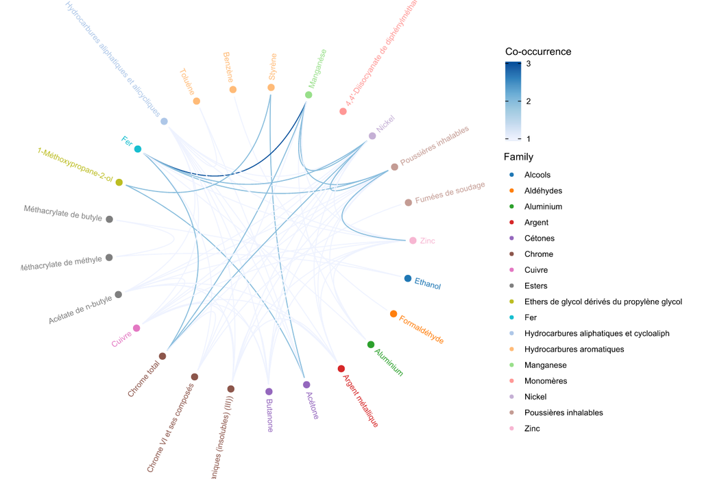

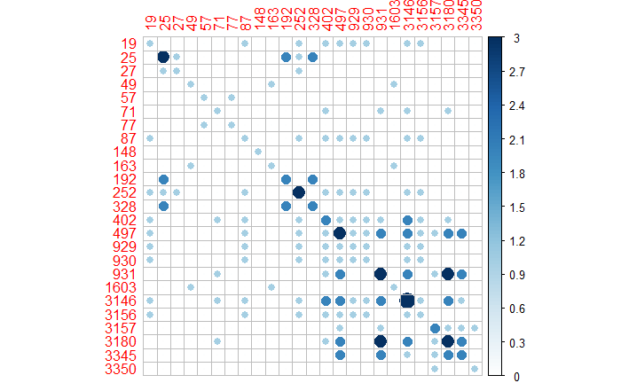

```r
# 2. A visualization of the matrix using the 'corrplot' package.
library(corrplot)

corrplot(cor_matrix, is.corr = FALSE)
```

```r
corrplot.mixed(cor_matrix, is.corr = FALSE,
               upper = "color", tl.col = "black",
               order = "hclust")
```

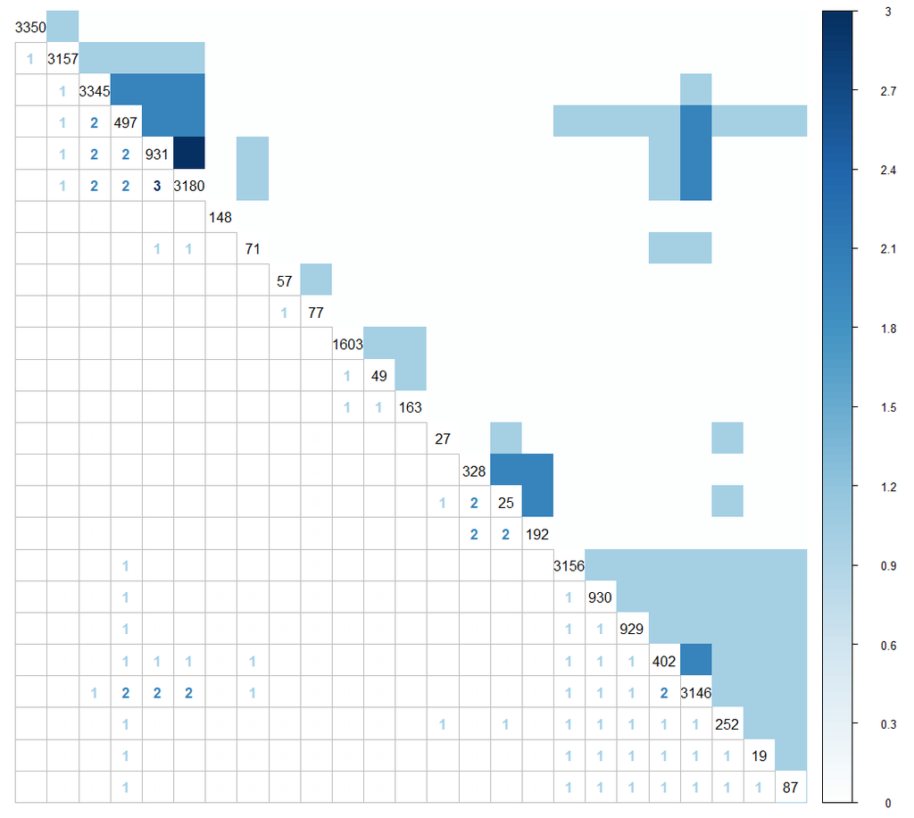

Plot a tree of the substances according to their family…

```r
category_tree_chart(sa_object, "family")
```

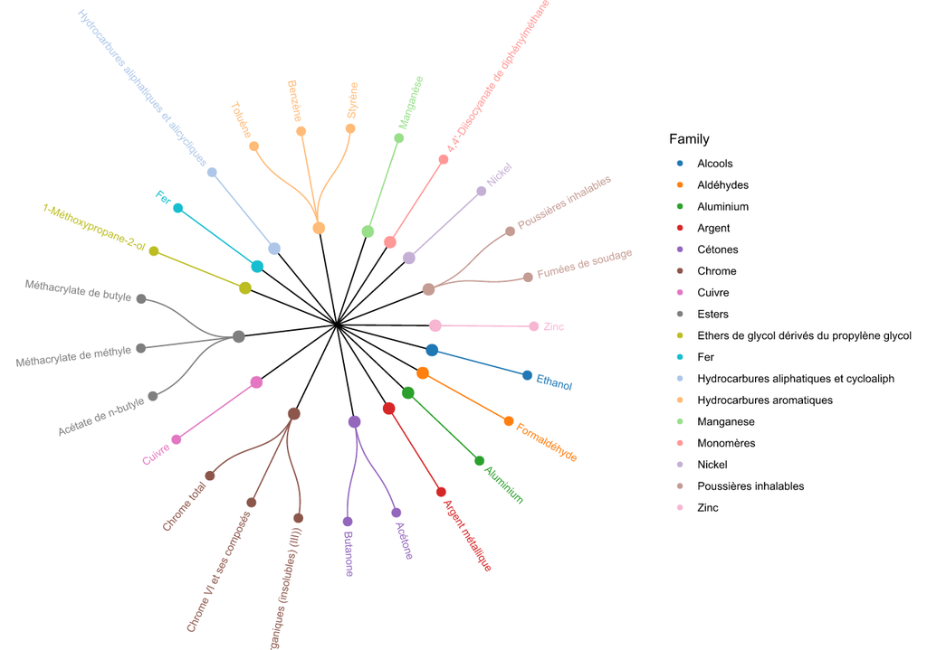